# CEE218 Assignment 3

Ximena Hasbach

11/1/2020

1. Select one (or at most, two) outcomes of interest that can be measured at the CBG, tract, or ZCTA level in the Bay Area. They must be continuous variables (like % of households in poverty) at this scale of analysis. At least one of the outcomes must also be available in the PUMS data at the individual or household level, so that one of your analyses can make use of PUMS data specifically. At this scale of analysis, the outcome can still be a continuous variable (like individual income) or convert to a categorical variable that can be made binary (like completing a college degree or not).

The outcome of interest I chose is percent employment with an independent variable of percent of population with at least a college degree. The result of the regression model is that this independent variable is statistically significant, with a very small p-value and a coefficient of 0.041.

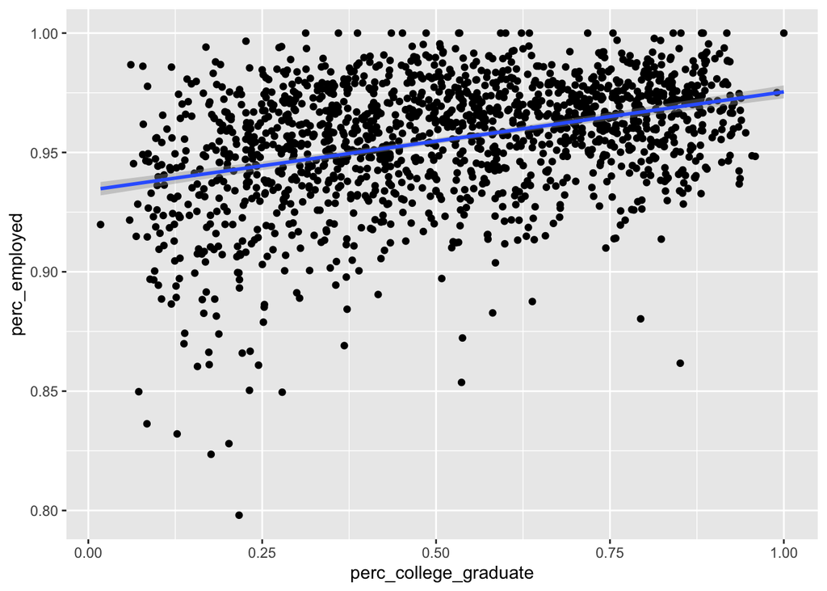

```
##
## Call:
## lm(formula = perc_employed ~ perc_college_graduate, data = bay_employed_educ_tract)
##
## Residuals:
##       Min        1Q    Median        3Q       Max
## -0.145010 -0.013015  0.002968  0.015884  0.053162
##
## Coefficients:
##                       Estimate Std. Error t value Pr(>|t|)
## (Intercept)           0.934089   0.001477  632.49   <2e-16 ***
## perc_college_graduate 0.041294   0.002593   15.93   <2e-16 ***
## ---
## Signif. codes:  0 '***' 0.001 '**' 0.01 '*' 0.05 '.' 0.1 ' ' 1
##
## Residual standard error: 0.02398 on 1575 degrees of freedom
## Multiple R-squared:  0.1387, Adjusted R-squared:  0.1382
## F-statistic: 253.7 on 1 and 1575 DF,  p-value: < 2.2e-16
```

The lm summary shows a our model to have a very small p-value, so we are confident in the statistical significance of the Percent College Graduate variable when considering the Percent Employment outcome.

2. Perform an individual or household level multiple regression analysis (with PUMS data for PUMAS in the Bay Area) using one of your outcomes of interest as the dependent variable and at least two independent variables (like language ability or commute time), which should be chosen based on some brief open-ended exploration of academic papers, news articles, or personal anecdotes that suggest a statistical relationship may be found between the independent and dependent variables. Compare your findings to those of your reviewed resources (keep in mind that if your geography and/or time period of analysis is different from that of your sources, those can be sources of differences in findings). Carefully describe your position on whether a causal claim can be made based on the results of your analysis, and feel free to comment on the degree to which your reviewed sources communicate correlation vs. causation in the same way. Be sure to make use of weights properly in the PUMS data.

PUMS vars: HINCP: household income ESP: employment status of parents PAOC: presence and age of own children WKHP: Usual hours worked per week past 12 months

| SERIALNO | SPORDER | WGTP | PWGTP | NP | HINCP | WKHP | PUMA | ST | ESP | PAOC | RAC1P | ST_label | ESP_label | PAOC_label | RAC1P_label | perc_white_alone |
| --- | --- | --- | --- | --- | --- | --- | --- | --- | --- | --- | --- | --- | --- | --- | --- | --- |
| 2014000000116 | 1 | 23 | 23 | 3 | 143000 | 40 | 07501 | 06 | b | 4 | 1 | NA | N/A (not own child of householder, and not child in subfamily) | Females with no own children | White alone | 1 |
| 2014000000795 | 1 | 14 | 14 | 3 | 200100 | 45 | 00105 | 06 | b | b | 1 | NA | N/A (not own child of householder, and not child in subfamily) | N/A (male/female under 16 years old/GQ) | White alone | 1 |
| 2014000001083 | 1 | 17 | 17 | 5 | 463600 | 84 | 08106 | 06 | b | b | 1 | NA | N/A (not own child of householder, and not child in subfamily) | N/A (male/female under 16 years old/GQ) | White alone | 1 |
| 2014000001125 | 1 | 10 | 10 | 2 | 155800 | 8 | 09501 | 06 | b | 4 | 6 | NA | N/A (not own child of householder, and not child in subfamily) | Females with no own children | Asian alone | 0 |
| 2014000001257 | 1 | 73 | 74 | 3 | 153000 | 25 | 08510 | 06 | b | 4 | 1 | NA | N/A (not own child of householder, and not child in subfamily) | Females with no own children | White alone | 1 |
| 2014000001420 | 1 | 17 | 16 | 2 | 22500 | 11 | 00110 | 06 | b | 4 | 1 | NA | N/A (not own child of householder, and not child in subfamily) | Females with no own children | White alone | 1 |
| 2014000001528 | 1 | 13 | 13 | 5 | 41100 | 8 | 00109 | 06 | b | 2 | 6 | NA | N/A (not own child of householder, and not child in subfamily) | Females with own children 6 to 17 years only | Asian alone | 0 |
| 2014000001562 | 1 | 0 | 1 | 1 | -60000 | 0 | 08103 | 06 | b | b | 1 | NA | N/A (not own child of householder, and not child in subfamily) | N/A (male/female under 16 years old/GQ) | White alone | 1 |
| 2014000001925 | 1 | 8 | 8 | 3 | 78900 | 0 | 01309 | 06 | b | 4 | 8 | NA | N/A (not own child of householder, and not child in subfamily) | Females with no own children | Some Other Race alone | 0 |
| 2014000001963 | 1 | 0 | 3 | 1 | -60000 | 0 | 01304 | 06 | b | b | 1 | NA | N/A (not own child of householder, and not child in subfamily) | N/A (male/female under 16 years old/GQ) | White alone | 1 |

[output cut: 9990 more lines]

[output not shown]

3. Perform at least one additional multiple regression analysis at the CBG, tract, or ZCTA level in the Bay Area, at which you may choose to use a similar outcome as the first analysis or a different one. Again, select at least two independent variables. Both independent and dependent variables can now come from other datasets besides the ACS, as long as they match the geographic scale of analysis. You are more than welcome to try matching this analysis with the first one as much as possible, so as to explicitly compare the results of an individual vs. ecological scale of analysis, or make this analysis completely different (in which case you should prepare a second set of literature review).

https://www.ncbi.nlm.nih.gov/pmc/articles/PMC6982282/ https://www.pewsocialtrends.org/2018/04/25/the-changing-profile-of-unmarried-parents/

| tract | perc_unemployed | perc_single_mother | perc_children_under_18 |
| --- | --- | --- | --- |
| 06055200202 | 0.0000000000 | 0.214414414 | 0.481081081 |
| 06055200400 | 0.0000000000 | 0.038421599 | 0.417445483 |
| 06055200900 | 0.0000000000 | 0.363636364 | 1.000000000 |
| 06085508101 | 0.0739320920 | 0.015334064 | 0.697152245 |
| 06085509202 | 0.0607734807 | 0.036832413 | 0.340699816 |
| 06085509304 | 0.0134952767 | 0.101214575 | 0.468286100 |
| 06085509401 | 0.0522222222 | 0.041111111 | 0.547777778 |
| 06085509801 | 0.0214438885 | 0.049320944 | 0.506075768 |
| 06085512307 | 0.0731834814 | 0.016204914 | 0.423941453 |
| 06085503204 | 0.0322359396 | 0.164609053 | 0.561728395 |

[output cut: 1566 more lines]

```
##
## Call:
## lm(formula = perc_unemployed ~ perc_single_mother + perc_children_under_18,
##     data = bay_employment_familytype)
##
## Residuals:
##      Min       1Q   Median       3Q      Max
## -0.07912 -0.02007 -0.00468  0.01441  0.37246
##
## Coefficients:
##                         Estimate Std. Error t value Pr(>|t|)
## (Intercept)             0.034813   0.003267  10.655   <2e-16 ***
## perc_single_mother      0.149781   0.013232  11.320   <2e-16 ***
## perc_children_under_18 -0.010164   0.007948  -1.279    0.201
## ---
## Signif. codes:  0 '***' 0.001 '**' 0.01 '*' 0.05 '.' 0.1 ' ' 1
##
## Residual standard error: 0.03171 on 1573 degrees of freedom
## Multiple R-squared:  0.0825, Adjusted R-squared:  0.08133
## F-statistic: 70.72 on 2 and 1573 DF,  p-value: < 2.2e-16
```